# *Stochastic Gradient Descent*

## *What is Gradient Descent and its Variants?*

*Gradient Descent is an optimization algorithm used for minimizing the cost function in various machine learning algorithms. It is basically used for updating the parameters of the learning model.*

*The goal of all supervised machine learning algorithms is to best estimate a target function (f) that maps input data (X) onto output variables (Y). This describes all classification and regression problems.*

*Some machine learning algorithms have coefficients that characterize the algorithms estimate for the target function (f). Different algorithms have different representations and different coefficients, but many of them require a process of optimization to find the set of coefficients that result in the best estimate of the target function.*

*Common examples of algorithms with coefficients that can be optimized using gradient descent are Linear Regression and Logistic Regression.*

*The evaluation of how close a fit a machine learning model estimates the target function can be calculated a number of different ways, often specific to the machine learning algorithm. The cost function involves evaluating the coefficients in the machine learning model by calculating a prediction for the model for each training instance in the dataset and comparing the predictions to the actual output values and calculating a sum or average error (such as the Sum of Squared Residuals or SSR in the case of linear regression).*

*The cost is calculated for a machine learning algorithm over the entire training dataset for each iteration of the gradient descent algorithm.*

### *Types of gradient Descent:*

#### *Batch Gradient Descent:*

*This is a type of gradient descent which processes all the training examples for each iteration of gradient descent. But if the number of training examples is large, then batch gradient descent is computationally very expensive. Hence if the number of training examples is large, then batch gradient descent is not preferred. Instead, we prefer to use stochastic gradient descent or mini-batch gradient descent. Batch gradient descent is the most common form of gradient descent described in machine learning.*

#### *Stochastic Gradient Descent:*

*This is a type of gradient descent which processes 1 training example per iteration. Hence, the parameters are being updated even after one iteration in which only a single example has been processed. Hence this is quite faster than batch gradient descent. But again, when the number of training examples is large, even then it processes only one example which can be additional overhead for the system as the number of iterations will be quite large.*

#### *Mini Batch gradient Descent:*

*This is a type of gradient descent which works faster than both batch gradient descent and stochastic gradient descent. Here b examples where b<m are processed per iteration. So even if the number of training examples is large, it is processed in batches of b training examples in one go. Thus, it works for larger training examples and that too with lesser number of iterations.*

## *Gradient Descent - In Detail*

*Gradient descent is an optimization algorithm used to find the values of parameters (coefficients) of a function (f) that minimizes a cost function (cost).*

*Gradient descent is best used when the parameters cannot be calculated analytically (e.g. using linear algebra) and must be searched for by an optimization algorithm.*

### *Gradient Descent Procedure*

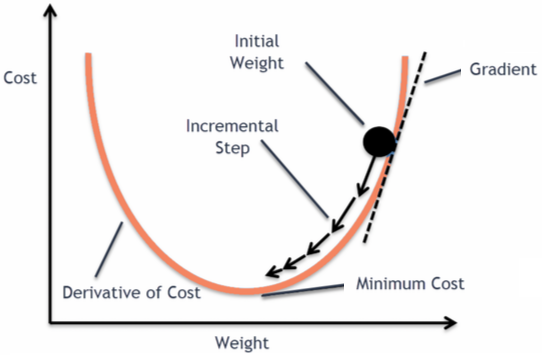

*The procedure starts off with initial values for the coefficient or coefficients for the function. These could be 0.0 or a small random value.*

$$coefficient = 0.0$$

*The cost of the coefficients is evaluated by plugging them into the function and calculating the cost.*

$$cost = f(coefficient)$$

*or*

$$cost = evaluate(f(coefficient))$$

*The derivative of the cost is calculated. The derivative is a concept from calculus and refers to the slope of the function at a given point. We need to know the slope so that we know the direction (sign) to move the coefficient values in order to get a lower cost on the next iteration.*

$$delta = derivative(cost)$$

*Now that we know from the derivative which direction is downhill, we can now update the coefficient values. A learning rate parameter (alpha) must be specified that controls how much the coefficients can change on each update.*

$$coefficient = coefficient – (alpha * delta)$$$$\theta := \theta -\alpha \frac{\delta}{\delta \theta}J(\theta)$$

*This process is repeated until the cost of the coefficients (cost) is 0.0 or close enough to zero to be good enough.*

*Repeating this process enough times will lead to the bottom of the curve (global minima) and you will know the values of the coefficients that result in the minimum cost.*

### *Stochastic Gradient Descent*

*Gradient descent can be slow to run on very large datasets. Because one iteration of the gradient descent algorithm requires a prediction for each instance in the training dataset, it can take a long time when you have many millions of instances.*

_In situations when you have large amounts of data, you can use a variation of gradient descent called *stochastic gradient descent*._

*In this variation, the gradient descent procedure described above is run but the update to the coefficients is performed for each training instance, rather than at the end of the batch of instances.*

*The first step of the procedure requires that the order of the training dataset is randomized. This is to mix up the order that updates are made to the coefficients. Because the coefficients are updated after every training instance, the updates will be noisy jumping all over the place, and so will the corresponding cost function. By mixing up the order for the updates to the coefficients, it harnesses this random walk and avoids it getting distracted or stuck.*

*The update procedure for the coefficients is the same as that above, except the cost is not summed over all training patterns, but instead calculated for one training pattern.*

*The learning can be much faster with stochastic gradient descent for very large training datasets and often you only need a small number of passes through the dataset to reach a good or good enough set of coefficients, e.g. 1-to-10 passes through the dataset.*

## *Important Pointers for GD*

1. *Plot Cost versus Time:*

*Collect and plot the cost values calculated by the algorithm each iteration. The expectation for a well performing gradient descent run is a decrease in cost each iteration. If it does not decrease, try reducing your learning rate. Learning Rate: The learning rate value is a small real value such as 0.1, 0.001 or 0.0001. Try different values for your problem and see which works best.*

1. *Rescale Inputs:*

*The algorithm will reach the minimum cost faster if the shape of the cost function is not skewed and distorted. You can achieved this by rescaling all of the input variables (X) to the same range, such as [0, 1] or [-1, 1].*

1. *Few Passes:*

*Stochastic gradient descent often does not need more than 1-to-10 passes through the training dataset to converge on good or good enough coefficients.*

1. *Plot Mean Cost:*

*The updates for each training dataset instance can result in a noisy plot of cost over time when using stochastic gradient descent. Taking the average over 10, 100, or 1000 updates can give you a better idea of the learning trend for the algorithm.*

## *Convergence trends in different variants of Gradient Descents*

*In case of **Batch Gradient Descent**, the algorithm follows a straight path towards the minimum. If the cost function is convex, then it converges to a global minimum and if the cost function is not convex, then it converges to a local minimum. Here the learning rate is typically held constant.*

*In case of **Stochastic gradient Descent** and **Mini-batch gradient descent**, the algorithm does not converge but keeps on fluctuating around the global minimum. Therefore in order to make it converge, we have to slowly change the learning rate. However the convergence of Stochastic gradient descent is much noisier as in one iteration, it processes only one training example.*

```python
# Packages / libraries

import os #provides functions for interacting with the operating system

import numpy as np
import pandas as pd
from matplotlib import pyplot as plt
import seaborn as sns
from numpy import random
from datetime import time

%matplotlib inline
import math
import random

import warnings
warnings.filterwarnings('ignore')
```

## *Modeling with SGDRegressor in sklearn*

_SGD is merely an optimization technique and does not correspond to a specific family of machine learning models. It is only a way to train a model. Often, an instance of SGDClassifier or SGDRegressor will have an equivalent estimator in the scikit-learn API, potentially using a different optimization technique. For example, using $SGDClassifier(loss='log')$ results in **logistic regression**, i.e. a model equivalent to LogisticRegression which is fitted via SGD instead of being fitted by one of the other solvers in LogisticRegression. Similarly, $SGDRegressor(loss='squared_loss', penalty='l2')$ and **Ridge** solve the same optimization problem, via different means._

*The advantages of Stochastic Gradient Descent are:*

- *Efficiency*
- *Ease of implementation (lots of opportunities for code tuning).*

*The disadvantages of Stochastic Gradient Descent include:*

- *SGD requires a number of hyperparameters such as the regularization parameter and the number of iterations.*
- *SGD is sensitive to feature scaling.*

```python
from prettytable import PrettyTable

from sklearn.datasets import load_boston

from sklearn import preprocessing
from sklearn.model_selection import train_test_split

from sklearn.linear_model import SGDRegressor

from sklearn.metrics import mean_squared_error
```

```python
boston_data=pd.DataFrame(load_boston().data,columns=load_boston().feature_names)
Y=load_boston().target
X=load_boston().data
x_train,x_test,y_train,y_test=train_test_split(X,Y,test_size=0.3)

print("X Shape: ",X.shape)
print("Y Shape: ",Y.shape)
print("X_Train Shape: ",x_train.shape)
print("X_Test Shape: ",x_test.shape)
print("Y_Train Shape: ",y_train.shape)
print("Y_Test Shape: ",y_test.shape)

# standardizing data
scaler = preprocessing.StandardScaler().fit(x_train)
x_train = scaler.transform(x_train)
x_test=scaler.transform(x_test)

## Adding the PRIZE Column in the data
train_data=pd.DataFrame(x_train)
train_data['price']=y_train
train_data.head(3)

x_test=np.array(x_test)
y_test=np.array(y_test)
```

```
X Shape:  (506, 13)
Y Shape:  (506,)
X_Train Shape:  (354, 13)
X_Test Shape:  (152, 13)
Y_Train Shape:  (354,)
Y_Test Shape:  (152,)
```

```python
# SkLearn SGD classifier
n_iter=100
clf_ = SGDRegressor(max_iter=n_iter)

clf_.fit(x_train, y_train)

y_pred_sksgd=clf_.predict(x_test)

print('Mean Squared Error :',mean_squared_error(y_test, y_pred_sksgd))
```

```
Mean Squared Error : 24.702975951902143
```

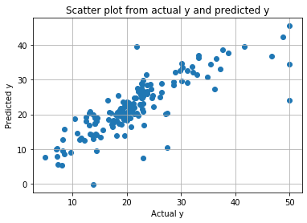

```python
plt.scatter(y_test,y_pred_sksgd)
plt.grid()
plt.xlabel('Actual y')
plt.ylabel('Predicted y')
plt.title('Scatter plot from actual y and predicted y')
plt.show()
```

## *Modeling Linear Regression using Custom Function*

### *Building SGD for Linear Regression*

*Linear Regression optimization problem is to optimize or MINimize the SQUARED ERROR.*

$$ERROR = (Actual Value - Predicted Value)$$

_For calculating the **Predicted Value (~Yi)**, we need the **Weights (Wi)** and the **Test data points (Xi)**. We need to do the **multiplication of W and X and add Bias b** to calculate the predicted value. Since W and X are vectors, we will take the Transpose of W ie W*T so that we can multiply it with X.*

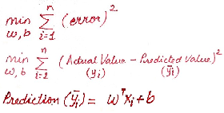

_Now in order to find the optimal W, the W_j+1 will be updated constantly as per the error difference in the previous W_j. To do this we will subtract the W*j with the derivative of our above Loss Function L(W,b) with respect to W, ie:*

$$W_j+1 = W_j - Derivative(Loss Function) w.r.t “W”$$

_Similarly our b_j+1 will also be updated as per the error difference in the previous b_j. To do this we will subtract the b*j with the derivative of our above Loss Function L(W,b) with respect to b, ie.*

$$b_j+1 = b_j — Derivative(Loss Function) w.r.t “b”$$

_Since we are implementing SGD, we will pick up random K points from the data to find our optimal W and b. Thus for every iteration, we need to iterate the gradient(derivative) calculations and we will update our W and for n*iteration times.*

*Code Snippet*

```
while(current_iter<=total_iter): #total_iteration = 100

    for i in range(k): # Small Batch of size K
        prediction=np.dot(w,x[i])+b
        w_gradient=w_gradient+(-2)*x[i]*(y[i]-(prediction))
        b_gradient=b_gradient+(-2)*(y[i]-(prediction))

    w=w-learning_rate*(w_gradient/k)
    b=b-learning_rate*(b_gradient/k)

    current_iter=current_iter+1
    learning_rate=learning_rate/dividebyrate
```

_We are dividing the w*gradient with k to get better result. And we are also reducing the learning rate by dividing it by a small number for every iteration so as to achieve the performance similar to that of the SKLearns SGDRegressor.*

```python
def Custom_SGD(train_data,learning_rate,n_iter,k,divideby):

    # Initially we will keep our W and B as 0 as per the Training Data
    w=np.zeros(shape=(1,train_data.shape[1]-1))
    b=0

    cur_iter=1
    while(cur_iter<=n_iter):

        # We will create a small training data set of size K
        temp=train_data.sample(k)

        # We create our X and Y from the above temp dataset
        y=np.array(temp['price'])
        x=np.array(temp.drop('price',axis=1))

        # We keep our initial gradients as 0
        w_gradient=np.zeros(shape=(1,train_data.shape[1]-1))
        b_gradient=0

        for i in range(k): # Calculating gradients for point in our K sized dataset
            prediction=np.dot(w,x[i])+b
            w_gradient=w_gradient+(-2)*x[i]*(y[i]-(prediction))
            b_gradient=b_gradient+(-2)*(y[i]-(prediction))

        #Updating the weights(W) and Bias(b) with the above calculated Gradients
        w=w-learning_rate*(w_gradient/k)
        b=b-learning_rate*(b_gradient/k)

        # Incrementing the iteration value
        cur_iter=cur_iter+1

        #Dividing the learning rate by the specified value
        learning_rate=learning_rate/divideby

    return w,b #Returning the weights and Bias
```

```python
def predict(x,w,b):
    y_pred=[]
    for i in range(len(x)):
        y=np.asscalar(np.dot(w,x[i])+b)
        y_pred.append(y)
    return np.array(y_pred)
```

### *Attempt 1*

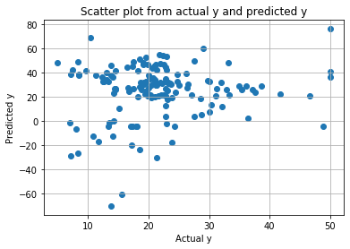

```
Mean Squared Error : 520.8010004108344
```

```python
# Learning rate = 1
# Batch Size K=10
# Divide the Learning rate by = 2

w,b=Custom_SGD(train_data,learning_rate=1,n_iter=100,divideby=2,k=10)
y_pred_customsgd=predict(x_test,w,b)

plt.scatter(y_test,y_pred_customsgd)
plt.grid()
plt.xlabel('Actual y')
plt.ylabel('Predicted y')
plt.title('Scatter plot from actual y and predicted y')
plt.show()
print('Mean Squared Error :',mean_squared_error(y_test, y_pred_customsgd))
```

### *Attempt 2*

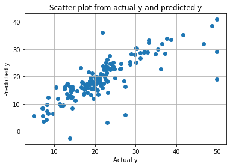

```
Mean Squared Error : 32.61427948263856
```

```python
# Learning rate = 0.001
# Iterations = 1000
# Divide the Learning rate by = 1 (ie. Not Dividing :-P)

w,b=Custom_SGD(train_data,learning_rate=0.001,n_iter=1000,divideby=1,k=10)
y_pred_customsgd=predict(x_test,w,b)

plt.scatter(y_test,y_pred_customsgd)
plt.grid()
plt.xlabel('Actual y')
plt.ylabel('Predicted y')
plt.title('Scatter plot from actual y and predicted y')
plt.show()
print('Mean Squared Error :',mean_squared_error(y_test, y_pred_customsgd))
```

## *Modeling with SGDClassifier in sklearn*

*Linear classifiers (SVM, logistic regression, etc.) with SGD training.*

_This estimator implements regularized linear models with stochastic gradient descent (SGD) learning: the gradient of the loss is estimated each sample at a time and the model is updated along the way with a decreasing strength schedule (aka learning rate). SGD allows minibatch (online/out-of-core) learning via the partial*fit method. For best results using the default learning rate schedule, the data should have zero mean and unit variance.*

*This implementation works with data represented as dense or sparse arrays of floating point values for the features. The model it fits can be controlled with the loss parameter; by default, it fits a linear support vector machine (SVM).*

*The regularizer is a penalty added to the loss function that shrinks model parameters towards the zero vector using either the squared euclidean norm L2 or the absolute norm L1 or a combination of both (Elastic Net). If the parameter update crosses the 0.0 value because of the regularizer, the update is truncated to 0.0 to allow for learning sparse models and achieve online feature selection.*

```python
df = pd.read_csv(r"C:\Users\PiyushSin\Desktop\datasets\run_walk.csv")
print(df.shape)
df.head()
```

```
(88588, 11)
```

|  | date | time | username | wrist | activity | acceleration_x | acceleration_y | acceleration_z | gyro_x | gyro_y | gyro_z |
| --- | --- | --- | --- | --- | --- | --- | --- | --- | --- | --- | --- |
| 0 | 2017-6-30 | 13:51:15:847724020 | viktor | 0 | 0 | 0.2650 | -0.7814 | -0.0076 | -0.0590 | 0.0325 | -2.9296 |
| 1 | 2017-6-30 | 13:51:16:246945023 | viktor | 0 | 0 | 0.6722 | -1.1233 | -0.2344 | -0.1757 | 0.0208 | 0.1269 |
| 2 | 2017-6-30 | 13:51:16:446233987 | viktor | 0 | 0 | 0.4399 | -1.4817 | 0.0722 | -0.9105 | 0.1063 | -2.4367 |
| 3 | 2017-6-30 | 13:51:16:646117985 | viktor | 0 | 0 | 0.3031 | -0.8125 | 0.0888 | 0.1199 | -0.4099 | -2.9336 |
| 4 | 2017-6-30 | 13:51:16:846738994 | viktor | 0 | 0 | 0.4814 | -0.9312 | 0.0359 | 0.0527 | 0.4379 | 2.4922 |

```python
df = df.drop(["date", "time", "username"], axis=1)
df.head()
```

|  | wrist | activity | acceleration_x | acceleration_y | acceleration_z | gyro_x | gyro_y | gyro_z |
| --- | --- | --- | --- | --- | --- | --- | --- | --- |
| 0 | 0 | 0 | 0.2650 | -0.7814 | -0.0076 | -0.0590 | 0.0325 | -2.9296 |
| 1 | 0 | 0 | 0.6722 | -1.1233 | -0.2344 | -0.1757 | 0.0208 | 0.1269 |
| 2 | 0 | 0 | 0.4399 | -1.4817 | 0.0722 | -0.9105 | 0.1063 | -2.4367 |
| 3 | 0 | 0 | 0.3031 | -0.8125 | 0.0888 | 0.1199 | -0.4099 | -2.9336 |
| 4 | 0 | 0 | 0.4814 | -0.9312 | 0.0359 | 0.0527 | 0.4379 | 2.4922 |

```python
print(df.describe())
data = df.values
X = data[:, 1:]  # all rows, no label
y = data[:, 0]  # all rows, label only
X_train, X_test, y_train, y_test = train_test_split(X, y, test_size=0.25, random_state=42)
```

```
              wrist      activity  acceleration_x  acceleration_y  \
count  88588.000000  88588.000000    88588.000000    88588.000000
mean       0.522170      0.500801       -0.074811       -0.562585
std        0.499511      0.500002        1.009299        0.658458
min        0.000000      0.000000       -5.350500       -3.299000
25%        0.000000      0.000000       -0.381800       -1.033500
50%        1.000000      1.000000       -0.059500       -0.759100
75%        1.000000      1.000000        0.355500       -0.241775
max        1.000000      1.000000        5.603300        2.668000

       acceleration_z        gyro_x        gyro_y        gyro_z
count    88588.000000  88588.000000  88588.000000  88588.000000
mean        -0.313956      0.004160      0.037203      0.022327
std          0.486815      1.253423      1.198725      1.914423
min         -3.753800     -4.430600     -7.464700     -9.480000
25%         -0.376000     -0.920700     -0.644825     -1.345125
50%         -0.221000      0.018700      0.039300      0.006900
75%         -0.085900      0.888800      0.733700      1.398200
max          1.640300      4.874200      8.498000     11.266200
```

```python
# Scale the data to be between -1 and 1
from sklearn.preprocessing import StandardScaler

scaler = StandardScaler()
scaler.fit(X_train)
X_train = scaler.transform(X_train)
X_test = scaler.transform(X_test)
```

```python
from sklearn.linear_model import SGDClassifier

model = SGDClassifier(loss="hinge", penalty="l2")
```

```python
model.fit(X_train, y_train)
```

```
SGDClassifier()
```

```python
model.score(X_test, y_test)
```

```
0.9003025240438886
```

```python
n_iters = [5, 10, 20, 50, 100, 1000]
scores = []
for n_iter in n_iters:
    model = SGDClassifier(loss="hinge", penalty="l2", max_iter=n_iter)
    model.fit(X_train, y_train)
    scores.append(model.score(X_test, y_test))
```

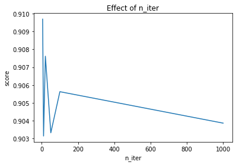

```python
plt.title("Effect of n_iter")
plt.xlabel("n_iter")
plt.ylabel("score")
plt.plot(n_iters, scores)
```

```python
# losses
losses = ["hinge", "log", "modified_huber", "perceptron", "squared_hinge"]
scores = []
for loss in losses:
    model = SGDClassifier(loss=loss, penalty="l2", max_iter=1000)
    model.fit(X_train, y_train)
    scores.append(model.score(X_test, y_test))
```

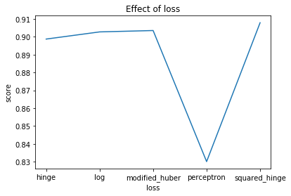

```python
plt.title("Effect of loss")
plt.xlabel("loss")
plt.ylabel("score")
x = np.arange(len(losses))
plt.xticks(x, losses)
plt.plot(x, scores)
```

```python
np.random.shuffle(data)
from sklearn.model_selection import GridSearchCV

params = {
    "loss" : ["hinge", "log", "squared_hinge", "modified_huber"],
    "alpha" : [0.0001, 0.001, 0.01, 0.1],
    "penalty" : ["l2", "l1", "none"],
}

model = SGDClassifier(max_iter=1000)
clf = GridSearchCV(model, param_grid=params)
```

```python
X = data[:, 1:]  # all rows, no label
y = data[:, 0]  # all rows, label only
clf.fit(X, y)
print(clf.best_score_)
```

```
0.9025601704204167
```

```python
print(clf.best_estimator_)
```

```
SGDClassifier(alpha=0.001, penalty='l1')
```

## *Modeling Logistic Regression with Custom Function*

*For Logistic Regression:*

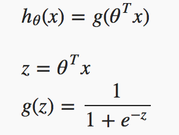

*Loss function:*

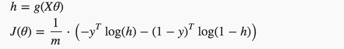

*Our goal is to minimize the loss function and the way we have to achive it is by increasing/decreasing the weights, i.e. fitting them. The question is, how do we know what parameters should be biggers and what parameters should be smallers? The answer is given by the derivative of the loss function with respect to each weight. It tells us how loss would change if we modified the parameters.*

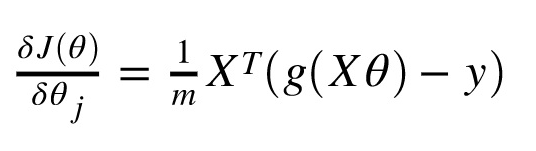

*Then we update the weights by substracting to them the derivative times the learning rate.*

```python
class LogisticRegression:
    def __init__(self, lr=0.01, num_iter=100000, fit_intercept=True, verbose=False):
        self.lr = lr
        self.num_iter = num_iter
        self.fit_intercept = fit_intercept
        self.verbose = verbose

    def __add_intercept(self, X):
        intercept = np.ones((X.shape[0], 1))
        return np.concatenate((intercept, X), axis=1)

    def __sigmoid(self, z):
        return 1 / (1 + np.exp(-z))
    def __loss(self, h, y):
        return (-y * np.log(h) - (1 - y) * np.log(1 - h)).mean()

    def fit(self, X, y):
        if self.fit_intercept:
            X = self.__add_intercept(X)

        # weights initialization
        self.theta = np.zeros(X.shape[1])

        for i in range(self.num_iter):
            z = np.dot(X, self.theta)
            h = self.__sigmoid(z)
            gradient = np.dot(X.T, (h - y)) / y.size
            self.theta -= self.lr * gradient

            if(self.verbose == True and i % 10000 == 0):
                z = np.dot(X, self.theta)
                h = self.__sigmoid(z)
                print(f'loss: {self.__loss(h, y)} \t')

    def predict_prob(self, X):
        if self.fit_intercept:
            X = self.__add_intercept(X)

        return self.__sigmoid(np.dot(X, self.theta))

    def predict(self, X, threshold):
        return self.predict_prob(X) >= threshold
```

```python
from sklearn.datasets import load_iris

iris = load_iris()
X = iris.data[:, :2]
y = (iris.target != 0) * 1
```

```python
model = LogisticRegression(lr=0.1, num_iter=300000)

model.fit(X, y)
```

```python
preds = model.predict(X, 0.3)
# accuracy
(preds == y).mean()
```

```
0.9933333333333333
```